# Lab 5

STAT 359 Data Visualization

# Overview

The goal of this Lab is to understand the concept of “layers” within ggplot. You should have already read through chapter 5 in Hadley Wickham’s *ggplot2: Elegant Graphics for Data Analysis* and completed lab 4.

# Dataset

The `athlete_events.csv` and `noc_regions.csv` files are from Kaggle.com. The `athlete_events.csv` is a historical dataset on the modern Olympic Games, including all the Games from Athens 1896 to Rio 2016. I scraped this data from www.sports-reference.com in May 2018. The `noc_regions.csv` is file which maps country abbreviation to country name.

- `ID` - Unique number for each athlete
- `Name` - Athlete’s name
- `Sex` - M or F
- `Age` - Integer
- `Height` - In centimeters
- `Weight` - In kilograms
- `Team` - Team Name
- `NOC` - National Olympic Committee 3-letter code
- `Games` - Year and season
- `Year` - Integer
- `Season` - Winter or summer
- `City` - Host city
- `Sport` - The sport in which the athlete competed
- `Event` - The event in which the athlete competed
- `Medal` - Gold, silver, bronze, or NA

# Task

Run the below R code prior to completing the tasks.

```r
# Import libraries
library(tidyverse)
library(ggthemes)

# Set theme
theme_set(theme_minimal())

# Import both athlete and region data
athlete_data <- read_csv('athlete_events.csv')
region_data <- read_csv('noc_regions.csv')

# Store the original row count of athlete data
original_row_count <- dim(athlete_data)[1]

# Combine region and athlete and region data. Convert appropriate columns to factors
athlete_data <- athlete_data %>%
  left_join(., region_data, by = c('NOC')) %>%
  mutate(Season = factor(Season),
         Medal = factor(Medal, levels = c('Gold', 'Silver', 'Bronze')),
         Sex = factor(Sex))

# Observe the imported data
head(athlete_data)
```

```
## # A tibble: 6 x 17
##      ID Name  Sex     Age Height Weight Team  NOC   Games  Year Season
##   <int> <chr> <fct> <int>  <int>  <dbl> <chr> <chr> <chr> <int> <fct>
## 1     1 A Di… M        24    180     80 China CHN   1992…  1992 Summer
## 2     2 A La… M        23    170     60 China CHN   2012…  2012 Summer
## 3     3 Gunn… M        24     NA     NA Denm… DEN   1920…  1920 Summer
## 4     4 Edga… M        34     NA     NA Denm… DEN   1900…  1900 Summer
## 5     5 Chri… F        21    185     82 Neth… NED   1988…  1988 Winter
## 6     5 Chri… F        21    185     82 Neth… NED   1988…  1988 Winter
## # ... with 6 more variables: City <chr>, Sport <chr>, Event <chr>,
## #   Medal <fct>, region <chr>, notes <chr>
```

0a. Did we increase the row count of athlete data after we joined new columns from the region data? Prove it.

```r
dim(athlete_data)[1] == original_row_count
```

```
## [1] TRUE
```

1a. Re-create the below plot and answer the below questions.

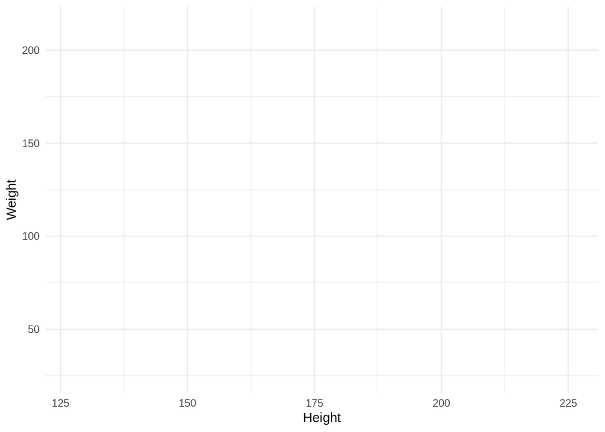

```r
ggplot(athlete_data, aes(x = Height, y = Weight, color = Sex))
```

1b. What’s missing from the above plot?

`Layers`

2a. Re-create the below plot and answer the below questions.

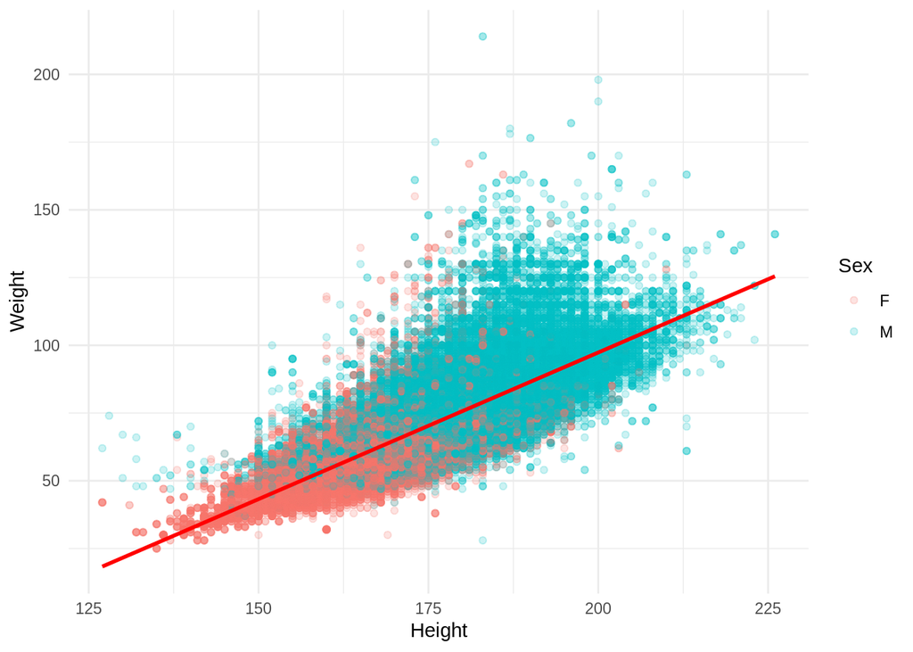

```r
ggplot(athlete_data, aes(x = Height, y = Weight, color = Sex)) +
  geom_point(alpha = .2) +
  geom_smooth(color = 'red', method = 'lm')
```

2b. What are the aesthetic mappings of this plot? In other words, what variables are mapped to what aspects of the visualization?

2c. How many layers are in this plot? What are the geometrc objects being used by these layers?

3a. Use the below `medal_winners` dataframe to recreate the below plot and answer the below questions. (hint: you will also need to use the original data set, in addition to the below)

```r
medal_winners <- filter(athlete_data, !is.na(Height)) %>%
  group_by(Medal) %>%
  summarise(count = n(), Height = mean(Height))
```

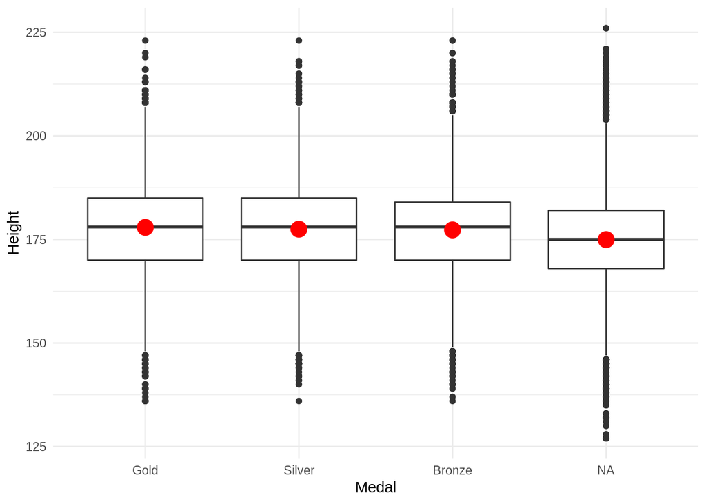

```r
ggplot(athlete_data, aes(x = Medal, Height)) +
  geom_boxplot() +
  geom_point(data = medal_winners, aes(x = Medal, y = Height), color = 'red', size = 5)
```

3b. How many layers are in this plot? What are the geometrc objects being used by these layers?

`2. A Boxplot (geom_boxplot) and a Scatterplot (geom_point).`

3c. What are the aesthetic mappings of this plot (do this for each layer)?

`For the Boxplot: Medal is mapped to the x-axis, while Height is mapped to y-axis. For the Scatterplot: Medal is mapped to x-axis, while Height is mapped to y-axis. Red is mapped to color aesthetic and the number five is mapped to the size aesthetic.`

4a. Use the below `medal_winners_2016` dataframe to recreate the below plot and answer the below questions. (hint: use facet_wrap())

```r
medal_winners_2016 <- athlete_data %>%
  filter((Year == 2016) & !is.na(Medal) & region %in% c('USA', 'China', 'Russia'))
```

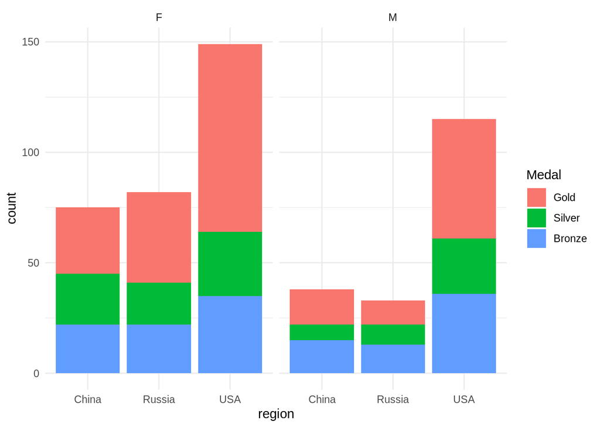

```r
ggplot(medal_winners_2016, aes(region, fill = Medal)) +
  geom_bar() +
  facet_wrap(~ Sex)
```

4b. How many layers are in this plot? What are the geometrc objects being used by these layers?

`1. A Barplot. The facet_wrap() is not a layer`

4c. What are the aesthetic mappings of this plot (do this for each layer)?

5. Recreate the below plot. Point out the key difference in your code between this visualization and the visualization in Question 2a.

`The order of the layers matters! In this case, unlike question 2a, the smoother is first and the scatterplot is second.`

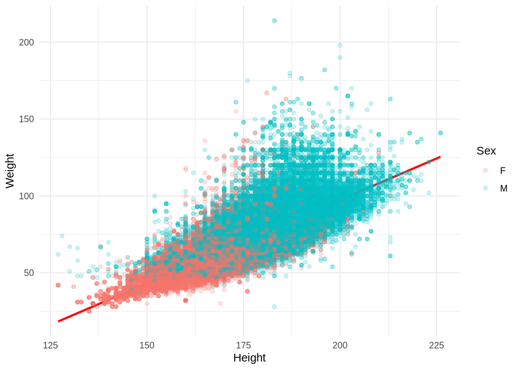

```r
ggplot(athlete_data, aes(x = Height, y = Weight, color = Sex)) +
  geom_smooth(color = 'red', method = 'lm') +
  geom_point(alpha = .2)
```